# CoSIA, an R package for Cross Species Investigation and Analysis

## 1.3 Use Cases with monogenic kidney disease-associated genes

The following use cases provide running examples of CoSIA applications with [Natera’s Monogenic Kidney Disease Panel](https://www.natera.com/resource-library/renasight/385-genes-associated-with-monogenic-disorders-linked-to-kidney-disease). We will perform id conversion, obtain and visualize gene expression data, and calculate and visualize the variation and diversity of gene expression across three species (human, mouse, & rat) and two tissues (kidney & heart).

### 1.3.1 Use Case #1: Converting gene symbols to Ensembl IDs

```r
CoSIAn_Obj_convert <- CoSIA::getConversions(CoSIAn_Obj)

str(CoSIAn_Obj_convert)
```

```
#> Formal class 'CoSIAn' [package "CoSIA"] with 13 slots
#>   ..@ gene_set         : chr [1:394] "CYP17A1" "OPLAH" "NOTCH2" "SALL4" ...
#>   ..@ i_species        : chr "h_sapiens"
#>   ..@ input_id         : chr "Symbol"
#>   ..@ o_species        : chr [1:3] "h_sapiens" "m_musculus" "r_norvegicus"
#>   ..@ output_ids       : chr "Ensembl_id"
#>   ..@ mapping_tool     : chr "annotationDBI"
#>   ..@ ortholog_database: chr "HomoloGene"
#>   ..@ converted_id     :'data.frame':    419 obs. of  4 variables:
#>   .. ..$ h_sapiens_symbol       : chr [1:419] "CYP17A1" "OPLAH" "NOTCH2" "SALL4" ...
#>   .. ..$ h_sapiens_ensembl_id   : chr [1:419] "ENSG00000148795" "ENSG00000178814" "ENSG00000134250" "ENSG00000101115" ...
#>   .. ..$ m_musculus_ensembl_id  : chr [1:419] "ENSMUSG00000003555" "ENSMUSG00000022562" "ENSMUSG00000027878" "ENSMUSG00000027547" ...
#>   .. ..$ r_norvegicus_ensembl_id: chr [1:419] "ENSRNOG00000020035" "ENSRNOG00000011781" "ENSRNOG00000018835" "ENSRNOG00000050035" ...
#>   ..@ map_tissues      : chr [1:2] "adult mammalian kidney" "heart"
#>   ..@ map_species      : chr [1:3] "h_sapiens" "m_musculus" "r_norvegicus"
#>   ..@ gex              :'data.frame':    1 obs. of  1 variable:
#>   .. ..$ X0: num 0
#>   ..@ metric_type      : chr "CV_Species"
#>   ..@ metric           :'data.frame':    1 obs. of  1 variable:
#>   .. ..$ X0: num 0
```

### 1.3.2 Use Case #2: Obtaining and visualizing curated non-diseased kidney and heart gene expression data for human, mouse, rat from Bgee

```r
CoSIAn_Obj_gex <- CoSIA::getGEx(CoSIAn_Obj_convert)

str(CoSIAn_Obj_gex)
```

```
#> Formal class 'CoSIAn' [package "CoSIA"] with 13 slots
#>   ..@ gene_set         : chr [1:394] "CYP17A1" "OPLAH" "NOTCH2" "SALL4" ...
#>   ..@ i_species        : chr "h_sapiens"
#>   ..@ input_id         : chr "Symbol"
#>   ..@ o_species        : chr [1:3] "h_sapiens" "m_musculus" "r_norvegicus"
#>   ..@ output_ids       : chr "Ensembl_id"
#>   ..@ mapping_tool     : chr "annotationDBI"
#>   ..@ ortholog_database: chr "HomoloGene"
#>   ..@ converted_id     :'data.frame':    419 obs. of  4 variables:
#>   .. ..$ h_sapiens_symbol       : chr [1:419] "CYP17A1" "OPLAH" "NOTCH2" "SALL4" ...
#>   .. ..$ h_sapiens_ensembl_id   : chr [1:419] "ENSG00000148795" "ENSG00000178814" "ENSG00000134250" "ENSG00000101115" ...
#>   .. ..$ m_musculus_ensembl_id  : chr [1:419] "ENSMUSG00000003555" "ENSMUSG00000022562" "ENSMUSG00000027878" "ENSMUSG00000027547" ...
#>   .. ..$ r_norvegicus_ensembl_id: chr [1:419] "ENSRNOG00000020035" "ENSRNOG00000011781" "ENSRNOG00000018835" "ENSRNOG00000050035" ...
#>   ..@ map_tissues      : chr [1:2] "adult mammalian kidney" "heart"
#>   ..@ map_species      : chr [1:3] "h_sapiens" "m_musculus" "r_norvegicus"
#>   ..@ gex              :'data.frame':    1998 obs. of  8 variables:
#>   .. ..$ Anatomical_entity_name: chr [1:1998] "adult mammalian kidney" "adult mammalian kidney" "adult mammalian kidney" "adult mammalian kidney" ...
#>   .. ..$ Ensembl_ID            : chr [1:1998] "ENSG00000285723" "ENSG00000170381" "ENSG00000171365" "ENSG00000171303" ...
#>   .. ..$ Sample_size           : int [1:1998] 23 23 23 23 23 23 23 23 23 23 ...
#>   .. ..$ Median_VST            : num [1:1998] 4.89 4.89 12.01 7.64 11.91 ...
#>   .. ..$ VST                   : chr [1:1998] "3.54564422116888, 4.92275162664869, 5.75395660803669, 6.68361521764915, 6.57409970660495, 6.21429873820157, 5.6"| __truncated__ "6.56205678528148, 6.54346016245676, 5.37017712209594, 5.47643859281315, 5.52574186004803, 5.14210338316864, 4.4"| __trunc…
#>   .. ..$ Experiment_ID         : chr [1:1998] "GSE30611, ERP003613, GSE30352, SRP058036, SRP012682" "GSE30611, ERP003613, GSE30352, SRP058036, SRP012682" "GSE30611, ERP003613, GSE30352, SRP058036, SRP012682" "GSE30611, ERP003613, GSE30352, SRP058036, SRP012682" ...
#>   .. ..$ Anatomical_entity_ID  : chr [1:1998] "UBERON:0000082" "UBERON:0000082" "UBERON:0000082" "UBERON:0000082" ...
#>   .. ..$ Species               : chr [1:1998] "Homo_sapiens" "Homo_sapiens" "Homo_sapiens" "Homo_sapiens" ...
#>   ..@ metric_type      : chr "CV_Species"
#>   ..@ metric           :'data.frame':    1 obs. of  1 variable:
#>   .. ..$ X0: num 0
```

```r
CoSIAn_Obj_gexplot <- CoSIA::plotSpeciesGEx(CoSIAn_Obj_gex, "adult mammalian kidney", "ENSG00000171766")

CoSIAn_Obj_gexplot
```

[interactive chart not shown]

### 1.3.3 Use Case #3: Gene expression variation across species for kidney tissue by calculating and visualizing Coeffient of Variation

```r
CoSIAn_Obj_CV <- CoSIA::getGExMetrics(CoSIAn_Obj_gex)

CoSIAn_Obj_CVplot <- plotCVGEx(CoSIAn_Obj_CV)

CoSIAn_Obj_CVplot
```

[interactive chart not shown]

### 1.3.4 Use Case #4: Gene expression diversity and specificity across tissues and species for monogenic kidney-disease associated genes

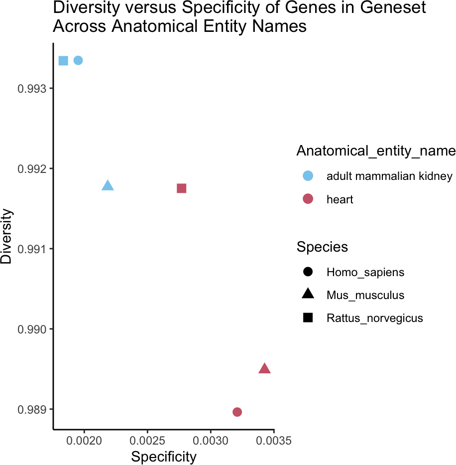

```r
CoSIAn_Obj_DS <- CoSIA::CoSIAn(gene_set = unique(monogenic_kidney_genes$Gene),
                            i_species = "h_sapiens",
                            o_species = c("h_sapiens", "m_musculus", "r_norvegicus"),
                            input_id = "Symbol",
                            output_ids = "Ensembl_id",
                            map_species = c("h_sapiens", "m_musculus", "r_norvegicus"),
                            map_tissues = c("adult mammalian kidney", "heart"),
                            mapping_tool = "annotationDBI",
                            ortholog_database = "HomoloGene",
                            metric_type = "DS_Tissue"
                            )

CoSIAn_Obj_DS <- CoSIA::getConversions(CoSIAn_Obj_DS)

CoSIAn_Obj_DS <- CoSIA::getGExMetrics(CoSIAn_Obj_DS)

CoSIAn_Obj_DSplot <- CoSIA::plotDSGEx(CoSIAn_Obj_DS)

CoSIAn_Obj_DSplot
```